# Linear regression analysis

First, let’s download the data, which represents the relationship between learning approaches and students’ achievements. It consists of 166 observations of 7 variables. Columns’ description:

- Gender: dichotomous variable (male or female)
- Age: represented in years, derived from the date of birth
- Attitude: Global attitude toward statistics
- Deep: stands for deep learning approach (intention to maximize understanding, with a true commitment to learning), derived from the corresponding survey questions
- Stra: stands for strategic learning approach (applying any strategies to maximize the chance of achieving the highest possible grades), derived from the corresponding survey questions
- Surf: stands for surface learning approach (memorizing without understanding, with a serious lack of personal engagement in the learning process), derived from the corresponding survey questions
- Points: exam points

```r
learning2014 <- read.csv("/Users/anastasia/IODS-project/data/learning2014.csv")
dim(learning2014)
```

```
## [1] 166   7
```

```r
str(learning2014)
```

```
## 'data.frame':    166 obs. of  7 variables:
##  $ gender  : Factor w/ 2 levels "F","M": 1 2 1 2 2 1 2 1 2 1 ...
##  $ age     : int  53 55 49 53 49 38 50 37 37 42 ...
##  $ attitude: num  3.7 3.1 2.5 3.5 3.7 3.8 3.5 2.9 3.8 2.1 ...
##  $ deep    : num  3.58 2.92 3.5 3.5 3.67 ...
##  $ stra    : num  3.38 2.75 3.62 3.12 3.62 ...
##  $ surf    : num  2.58 3.17 2.25 2.25 2.83 ...
##  $ points  : int  25 12 24 10 22 21 21 31 24 26 ...
```

Now we can conduct a graphical analysis:

```r
library(GGally)
```

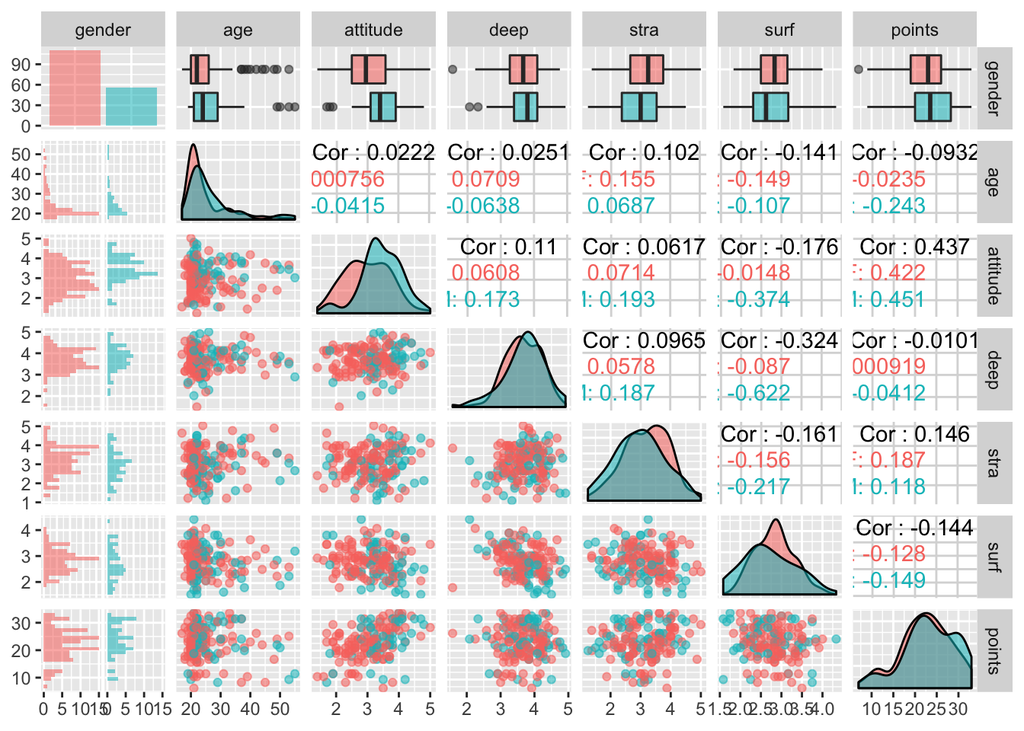

```r
library(ggplot2)

# creates pairs plot
p <- ggpairs(learning2014, mapping = aes(col = gender, alpha = 0.3), lower = list(combo = wrap("facethist", bins = 20)))
p
```

The very first line of the pairs plot above shows the histogram of gender distribution (dichotomous variable) and genderwise box plots where the ends of the box are the upper and lower quartiles, and the median is marked by a vertical line inside the box. The first column shows genderwise distributions of “age”, “attitude”, “deep”, “stra”, “surf” and “points”. Pink color refers to females, blue to males.  
From the rest of the plot we can see:

- on the diagonal the distributions of all the continuous variables in our scope
- on the upper triangle genderwise correlation coefficients
- on the lower triangle scatter plots which show relationships between two variables

Gender distribution is imbalanced: twice more females than males. Age distribution is severely skewed towards young ages. The rest of distributions are also skewed, but not severely, and mostly have two picks.  
Now we conduct the linear regression analysis, where “points” is a dependent variable, and explanatory variables are represented by “attitude”, “stra” and “surf” – which have the highest correlation with our target.

```r
# creates a regression model with multiple explanatory variables

my_model <- lm(points ~ attitude + stra + surf, data = learning2014)

# prints a summary of the model
summary(my_model)
```

```
##
## Call:
## lm(formula = points ~ attitude + stra + surf, data = learning2014)
##
## Residuals:
##      Min       1Q   Median       3Q      Max
## -17.1550  -3.4346   0.5156   3.6401  10.8952
##
## Coefficients:
##             Estimate Std. Error t value Pr(>|t|)
## (Intercept)  11.0171     3.6837   2.991  0.00322 **
## attitude      3.3952     0.5741   5.913 1.93e-08 ***
## stra          0.8531     0.5416   1.575  0.11716
## surf         -0.5861     0.8014  -0.731  0.46563
## ---
## Signif. codes:  0 '***' 0.001 '**' 0.01 '*' 0.05 '.' 0.1 ' ' 1
##
## Residual standard error: 5.296 on 162 degrees of freedom
## Multiple R-squared:  0.2074, Adjusted R-squared:  0.1927
## F-statistic: 14.13 on 3 and 162 DF,  p-value: 3.156e-08
```

The summary of the model suggests the following interpretation:

- One unit increase in **attitude** variable provides **3.4** units increase in points. The higher student’s attitude towards statistics, the higher grade he gains on the exam. Positive attitude is important for achievement.
- One unit increase in **strategic learning approach** increases points by **0.9** units.
- One unit increase in **surface learning approach** decreases points by **0.6** units.

However, p-values suggest that only “attitude” is significant in the model on 5% significance level. If you are not familiar with the p-values, they are used to determine statistical significance in a hypothesis test (in our case, if coefficients of linear regression are zero):

- High P values: our data are likely with a true null.
- Low P values: our data are unlikely with a true null.

where true null stands for the situation when corresponding coefficient is zero (zero influence on “points”).  
We fit another model without a “surf” variable:

```r
# creates a regression model with multiple explanatory variables
my_model2 <- lm(points ~ attitude + stra, data = learning2014)

# prints a summary of the model
summary(my_model2)
```

```
##
## Call:
## lm(formula = points ~ attitude + stra, data = learning2014)
##
## Residuals:
##      Min       1Q   Median       3Q      Max
## -17.6436  -3.3113   0.5575   3.7928  10.9295
##
## Coefficients:
##             Estimate Std. Error t value Pr(>|t|)
## (Intercept)   8.9729     2.3959   3.745  0.00025 ***
## attitude      3.4658     0.5652   6.132 6.31e-09 ***
## stra          0.9137     0.5345   1.709  0.08927 .
## ---
## Signif. codes:  0 '***' 0.001 '**' 0.01 '*' 0.05 '.' 0.1 ' ' 1
##
## Residual standard error: 5.289 on 163 degrees of freedom
## Multiple R-squared:  0.2048, Adjusted R-squared:  0.1951
## F-statistic: 20.99 on 2 and 163 DF,  p-value: 7.734e-09
```

- One unit increase in **attitude** variable provides **3.5** units increase in points. The higher student’s attitude towards statistics, the higher grade he gains on the exam. Positive attitude is important for achievement.
- One unit increase in **strategic learning approach** increases points by **0.9** units. The model explains 20% of variance in the data, since $R^2 = 0.2$.

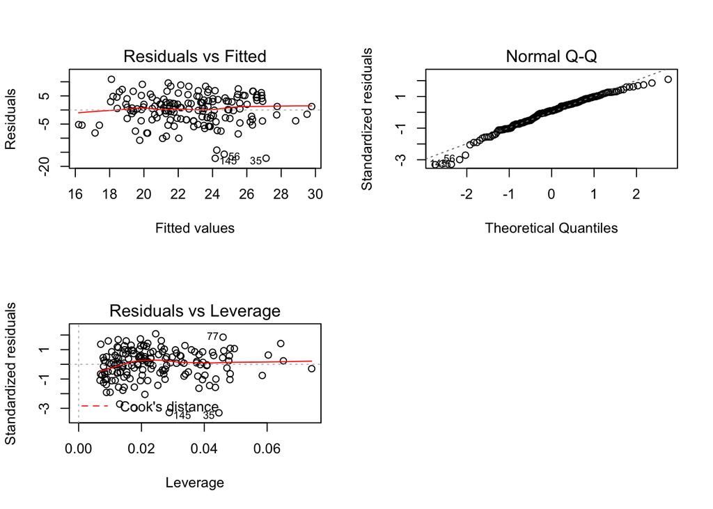

```r
# set plots' locations
par(mfrow = c(2,2))
# creates diagnostic plots
plot(my_model, which=c(1, 2, 5))
```